# ch12.rmd

Brea Koenes

12/24/2022

# Chapter 12

## 5

```r
summary(bald_eagles)
```

```
##       year          count            hours       count_per_hour
##  Min.   :1981   Min.   : 0.000   Min.   :134.0   Min.   :0.000000
##  1st Qu.:1990   1st Qu.: 1.000   1st Qu.:164.0   1st Qu.:0.005618
##  Median :1999   Median : 2.000   Median :178.0   Median :0.011976
##  Mean   :1999   Mean   : 2.811   Mean   :184.6   Mean   :0.014266
##  3rd Qu.:2008   3rd Qu.: 4.000   3rd Qu.:214.0   3rd Qu.:0.018692
##  Max.   :2017   Max.   :12.000   Max.   :248.8   Max.   :0.060377
##  count_per_week
##  Min.   : 0.0000
##  1st Qu.: 0.9438
##  Median : 2.0120
##  Mean   : 2.3967
##  3rd Qu.: 3.1402
##  Max.   :10.1434
```

```r
require(ggformula)
```

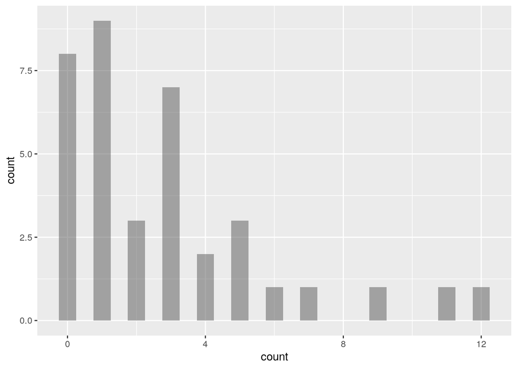

```r
gf_histogram(~count, data = bald_eagles)
```

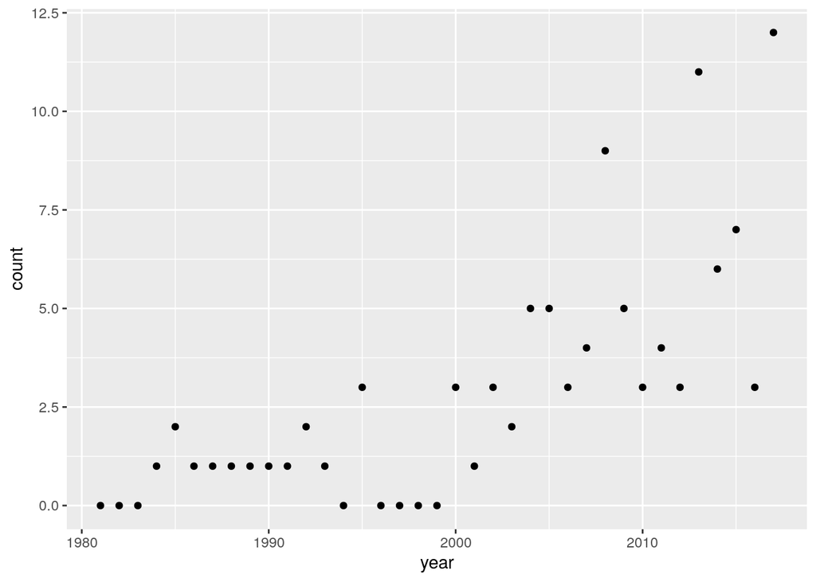

```r
gf_point(count~year, data = bald_eagles)
```

Count increases with year

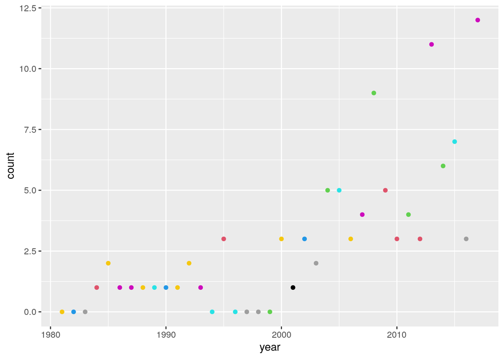

```r
gf_point(count~year, data = bald_eagles, color = bald_eagles$hours)
```

Hours looks associated positively with count over the years.

## 6

```r
summary(bald_eagles)
```

```
##       year          count            hours       count_per_hour
##  Min.   :1981   Min.   : 0.000   Min.   :134.0   Min.   :0.000000
##  1st Qu.:1990   1st Qu.: 1.000   1st Qu.:164.0   1st Qu.:0.005618
##  Median :1999   Median : 2.000   Median :178.0   Median :0.011976
##  Mean   :1999   Mean   : 2.811   Mean   :184.6   Mean   :0.014266
##  3rd Qu.:2008   3rd Qu.: 4.000   3rd Qu.:214.0   3rd Qu.:0.018692
##  Max.   :2017   Max.   :12.000   Max.   :248.8   Max.   :0.060377
##  count_per_week
##  Min.   : 0.0000
##  1st Qu.: 0.9438
##  Median : 2.0120
##  Mean   : 2.3967
##  3rd Qu.: 3.1402
##  Max.   :10.1434
```

```r
bald_eagles_model <- stan_glm(count ~ year + hours,
                       data = bald_eagles,
                       family = gaussian,
                       prior_intercept = normal(4, 2),
                       prior = normal(2, 0.5),
                       prior_aux = exponential(0.0008),
                       chains = 4, iter = 5000*2, seed = 84735)
prior_summary(bald_eagles_model)
```

```
## Priors for model 'bald_eagles_model'
## ------
## Intercept (after predictors centered)
##  ~ normal(location = 4, scale = 2)
##
## Coefficients
##  ~ normal(location = [2,2], scale = [0.5,0.5])
##
## Auxiliary (sigma)
##  ~ exponential(rate = 8e-04)
## ------
## See help('prior_summary.stanreg') for more details
```

$$
$$\begin{align*}
data: \\
Y_i | \beta_0,\beta_1,\beta_2,\sigma \\
\tilde \\ \\
N(\mu_i, \sigma^2)
\\ with \\
\mu_i = \beta_0 + \beta_1X_{i1} + \beta_2X_{i2} \\
\end{align*}$$
$$

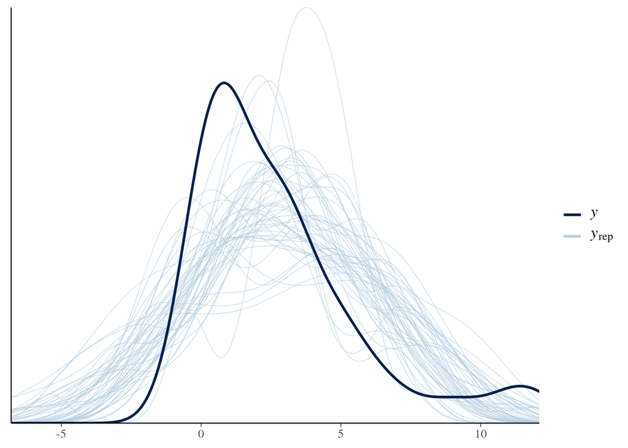

```r
pp_check(bald_eagles_model)
```

## 7

Poisson is more appropriate because it works with discrete data that can only be equal to or greater than zero. Our data is integers that are greater than or equal to 0.

```r
bald_eagles_model2 <- stan_glm(count ~ year + hours,
                                 data = bald_eagles,
                                 family = poisson,
                                 prior_intercept = normal(4, 2),
                                 prior = normal(2, 0.5),
                                 chains = 4, iter = 5000*2, seed = 84735)
prior_summary(bald_eagles_model2)
```

```
## Priors for model 'bald_eagles_model2'
## ------
## Intercept (after predictors centered)
##  ~ normal(location = 4, scale = 2)
##
## Coefficients
##  ~ normal(location = [2,2], scale = [0.5,0.5])
## ------
## See help('prior_summary.stanreg') for more details
```

$$
$$\begin{align*}
data: \\
Y_i | \beta_0,\beta_1,\beta_2 \\
\tilde \\ \\
Pois(\lambda_i)
\\ with \\
\log(\lambda_i) = \beta_0 + \beta_1X_{i1} + \beta_2X_{i2} \\
\end{align*}$$
$$

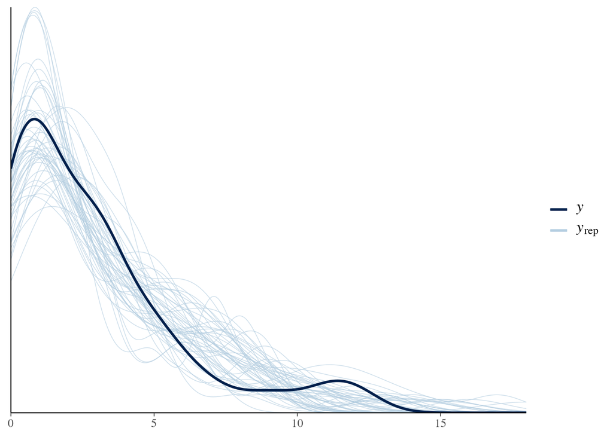

```r
pp_check(bald_eagles_model2)
```

The model is “good” and its assumptions are appropriate for the bald eagle analysis.

## 8

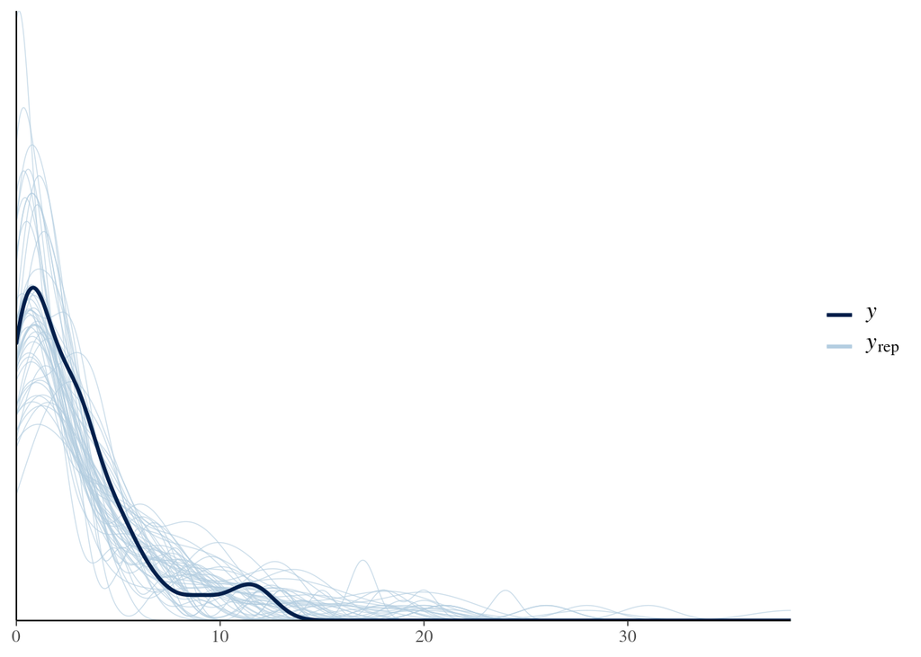

```r
bald_eagles_model3 <- stan_glm(count ~ year + hours,
                               data = bald_eagles,
                               family = neg_binomial_2,
                               prior_intercept = normal(4, 2),
                               prior = normal(2, 0.5),
                               prior_aux = exponential(1, autoscale = TRUE),
                               chains = 4, iter = 5000*2, seed = 84735)
pp_check(bald_eagles_model3)
```

The model is “good” and its assumptions are appropriate.

$$
$$\begin{align*}
data: \\
Y_i | \beta_0,\beta_1,\beta_2,r \\
\tilde \\ \\
NegBin(\mu_i,r)
\\ with \\
\log(\mu_i) = \beta_0 + \beta_1X_{i1} + \beta_2X_{i2} \\
\end{align*}$$
$$

```r
tidy(bald_eagles_model3, conf.int = TRUE, conf.level = 0.80)
```

```
## # A tibble: 3 × 5
##   term          estimate std.error   conf.low conf.high
##   <chr>            <dbl>     <dbl>      <dbl>     <dbl>
## 1 (Intercept) -157.       35.6     -203.      -113.
## 2 year           0.0787    0.0179     0.0560     0.102
## 3 hours          0.00459   0.00560   -0.00260    0.0120
```

```r
tidy(bald_eagles_model3, conf.int = TRUE, conf.level = 0.95)
```

```
## # A tibble: 3 × 5
##   term          estimate std.error   conf.low conf.high
##   <chr>            <dbl>     <dbl>      <dbl>     <dbl>
## 1 (Intercept) -157.       35.6     -231.       -90.6
## 2 year           0.0787    0.0179     0.0447     0.116
## 3 hours          0.00459   0.00560   -0.00645    0.0161
```

When controlling for the number of observation hours, we have ample evidence that the rate of eagle sightings has increased over time.

## 9

The model is fair? I don’t believe that there is bias in the data collection process.

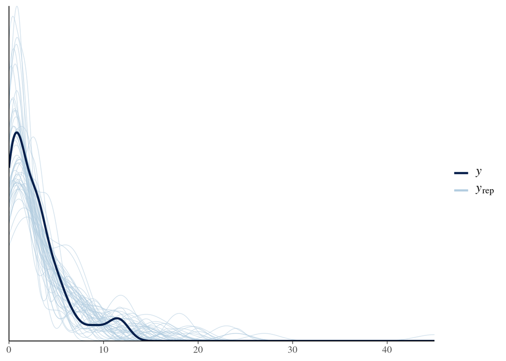

```r
pp_check(bald_eagles_model3)
```

Our pp_check() shows that our assumptions are reasonable. Our model is not very “wrong.”

```r
prediction_summary(model = bald_eagles_model3, data = bald_eagles)
```

```
##      mae mae_scaled within_50 within_95
## 1 1.0865  0.5328951 0.8378378         1
```

Our model is pretty accurate given the scaled mae above.